# Supervised Learning Regression Project: Cars4U

## Problem Statement

### Business Context

There is a huge demand for used cars in the Indian Market today. As sales of new cars have slowed down in the recent past, the pre-owned car market has continued to grow over the past years and is larger than the new car market now. Cars4U is a budding tech start-up that aims to find footholes in this market.

In 2018-19, while new car sales were recorded at 3.6 million units, around 4 million second-hand cars were bought and sold. There is a slowdown in new car sales and that could mean that the demand is shifting towards the pre-owned market. In fact, some car sellers replace their old cars with pre-owned cars instead of buying new ones. Unlike new cars, where price and supply are fairly deterministic and managed by OEMs (Original Equipment Manufacturer / except for dealership level discounts which come into play only in the last stage of the customer journey), used cars are very different beasts with huge uncertainty in both pricing and supply. Keeping this in mind, the pricing scheme of these used cars becomes important in order to grow in the market.

As a senior data scientist at Cars4U, you have to come up with a pricing model that can effectively predict the price of used cars and can help the business in devising profitable strategies using differential pricing. For example, if the business knows the market price, it will never sell anything below it.

### Objective

To explore and visualize the dataset, build a linear regression model to predict the prices of used cars, and generate a set of insights and recommendations that will help the business.

### Data Description

The data contains the different attributes of used cars sold in different locations. The detailed data dictionary is given below.

**Data Dictionary**

- S.No.: Serial number
- Name: Name of the car which includes brand name and model name
- Location: Location in which the car is being sold or is available for purchase (cities)
- Year: Manufacturing year of the car
- Kilometers_driven: The total kilometers driven in the car by the previous owner(s) in km
- Fuel_Type: The type of fuel used by the car (Petrol, Diesel, Electric, CNG, LPG)
- Transmission: The type of transmission used by the car (Automatic/Manual)
- Owner_Type: Type of ownership
- Mileage: The standard mileage offered by the car company in kmpl or km/kg
- Engine: The displacement volume of the engine in CC
- Power: The maximum power of the engine in bhp
- Seats: The number of seats in the car
- New_Price: The price of a new car of the same model in INR Lakhs (1 Lakh = 100,000 INR)
- Price: The price of the used car in INR Lakhs

## Importing necessary libraries

```python
# this will help in making the Python code more structured automatically (good coding practice)
%load_ext nb_black

# Libraries to help with reading and manipulating data
import numpy as np
import pandas as pd

# Libraries to help with data visualization
import matplotlib.pyplot as plt
import seaborn as sns

# to build linear regression_model
from sklearn.linear_model import LinearRegression

# to check model performance
from sklearn.metrics import mean_absolute_error, mean_squared_error, r2_score

sns.set()

# Removes the limit for the number of displayed columns
pd.set_option("display.max_columns", None)
# Sets the limit for the number of displayed rows
pd.set_option("display.max_rows", 200)
```

```
The nb_black extension is already loaded. To reload it, use:
  %reload_ext nb_black
```

## Loading the dataset

```python
# loading the dataset
df = pd.read_csv("used_cars_data.csv", engine="python")
```

## Data Overview

- Observations
- Sanity checks

```python
df.head()
```

|  | S.No. | Name | Location | Year | Kilometers_Driven | Fuel_Type | Transmission | Owner_Type | Mileage | Engine | Power | Seats | New_Price | Price |
| --- | --- | --- | --- | --- | --- | --- | --- | --- | --- | --- | --- | --- | --- | --- |
| 0 | 0 | Maruti Wagon R LXI CNG | Mumbai | 2010 | 72000 | CNG | Manual | First | 26.6 km/kg | 998 CC | 58.16 bhp | 5.0 | 5.51 | 1.75 |
| 1 | 1 | Hyundai Creta 1.6 CRDi SX Option | Pune | 2015 | 41000 | Diesel | Manual | First | 19.67 kmpl | 1582 CC | 126.2 bhp | 5.0 | 16.06 | 12.50 |
| 2 | 2 | Honda Jazz V | Chennai | 2011 | 46000 | Petrol | Manual | First | 18.2 kmpl | 1199 CC | 88.7 bhp | 5.0 | 8.61 | 4.50 |
| 3 | 3 | Maruti Ertiga VDI | Chennai | 2012 | 87000 | Diesel | Manual | First | 20.77 kmpl | 1248 CC | 88.76 bhp | 7.0 | 11.27 | 6.00 |
| 4 | 4 | Audi A4 New 2.0 TDI Multitronic | Coimbatore | 2013 | 40670 | Diesel | Automatic | Second | 15.2 kmpl | 1968 CC | 140.8 bhp | 5.0 | 53.14 | 17.74 |

```python
np.random.seed(2)
df.sample(10)
```

|  | S.No. | Name | Location | Year | Kilometers_Driven | Fuel_Type | Transmission | Owner_Type | Mileage | Engine | Power | Seats | New_Price | Price |
| --- | --- | --- | --- | --- | --- | --- | --- | --- | --- | --- | --- | --- | --- | --- |
| 4584 | 4584 | Tata Tigor 1.05 Revotorq XT | Kochi | 2018 | 28973 | Diesel | Manual | First | 24.7 kmpl | 1047 CC | 69 bhp | 5.0 | 7.15 | 6.64 |
| 6505 | 6505 | Volkswagen Vento Diesel Highline | Chennai | 2011 | 76041 | Diesel | Manual | First | 20.54 kmpl | 1598 CC | 103.6 bhp | 5.0 | 13.23 | NaN |
| 3675 | 3675 | Maruti Swift VDI | Ahmedabad | 2012 | 65000 | Diesel | Manual | First | 22.9 kmpl | 1248 CC | 74 bhp | 5.0 | 7.88 | 3.90 |
| 5654 | 5654 | Hyundai i20 Magna Optional 1.2 | Kochi | 2014 | 42315 | Petrol | Manual | First | 18.5 kmpl | 1197 CC | 82.9 bhp | 5.0 | 10.25 | 4.79 |
| 4297 | 4297 | Toyota Camry 2.5 G | Mumbai | 2014 | 68400 | Petrol | Automatic | First | 12.98 kmpl | 2494 CC | 178.4 bhp | 5.0 | 40.62 | 13.50 |
| 2603 | 2603 | Mercedes-Benz New C-Class 220 CDI AT | Jaipur | 2010 | 74213 | Diesel | Automatic | First | 14.84 kmpl | 2143 CC | 170 bhp | 5.0 | 49.49 | 11.50 |
| 4337 | 4337 | Volkswagen Vento Petrol Highline AT | Kochi | 2014 | 32283 | Petrol | Automatic | Second | 14.4 kmpl | 1598 CC | 103.6 bhp | 5.0 | 13.23 | 5.41 |
| 6625 | 6625 | Maruti Swift VDI BSIV | Kolkata | 2012 | 72000 | Diesel | Manual | First | 17.8 kmpl | 1248 CC | NaN | 5.0 | 7.88 | NaN |
| 2846 | 2846 | Skoda Superb Elegance 1.8 TSI AT | Kochi | 2011 | 73783 | Petrol | Automatic | Second | 13.7 kmpl | 1798 CC | 157.75 bhp | 5.0 | 33.36 | 5.23 |
| 1237 | 1237 | Audi Q3 2.0 TDI Quattro | Hyderabad | 2013 | 60000 | Diesel | Automatic | First | 17.32 kmpl | 1968 CC | 184 bhp | 5.0 | 44.80 | 21.00 |

1) There are some NaN in the price column. Price is the dependent variable. We will have to drop those rows.  
2) No data for accident history

```python
df.isnull().sum().sort_values(ascending=False)
```

```
Price                1234
Power                 175
Seats                  53
Engine                 46
Mileage                 2
S.No.                   0
Name                    0
Location                0
Year                    0
Kilometers_Driven       0
Fuel_Type               0
Transmission            0
Owner_Type              0
New_Price               0
dtype: int64
```

```python
df.duplicated().sum()
```

```
0
```

```python
df.info()
```

```
<class 'pandas.core.frame.DataFrame'>
RangeIndex: 7253 entries, 0 to 7252
Data columns (total 14 columns):
 #   Column             Non-Null Count  Dtype
---  ------             --------------  -----
 0   S.No.              7253 non-null   int64
 1   Name               7253 non-null   object
 2   Location           7253 non-null   object
 3   Year               7253 non-null   int64
 4   Kilometers_Driven  7253 non-null   int64
 5   Fuel_Type          7253 non-null   object
 6   Transmission       7253 non-null   object
 7   Owner_Type         7253 non-null   object
 8   Mileage            7251 non-null   object
 9   Engine             7207 non-null   object
 10  Power              7078 non-null   object
 11  Seats              7200 non-null   float64
 12  New_Price          7253 non-null   float64
 13  Price              6019 non-null   float64
dtypes: float64(3), int64(3), object(8)
memory usage: 793.4+ KB
```

1) Price is a float variable  
2) Milage engine and power will have to converted from object to float for analysis

```python
df.describe(include="all").T
```

|  | count | unique | top | freq | mean | std | min | 25% | 50% | 75% | max |
| --- | --- | --- | --- | --- | --- | --- | --- | --- | --- | --- | --- |
| S.No. | 7253.0 | NaN | NaN | NaN | 3626.0 | 2093.905084 | 0.0 | 1813.0 | 3626.0 | 5439.0 | 7252.0 |
| Name | 7253 | 2041 | Mahindra XUV500 W8 2WD | 55 | NaN | NaN | NaN | NaN | NaN | NaN | NaN |
| Location | 7253 | 11 | Mumbai | 949 | NaN | NaN | NaN | NaN | NaN | NaN | NaN |
| Year | 7253.0 | NaN | NaN | NaN | 2013.365366 | 3.254421 | 1996.0 | 2011.0 | 2014.0 | 2016.0 | 2019.0 |
| Kilometers_Driven | 7253.0 | NaN | NaN | NaN | 58699.063146 | 84427.720583 | 171.0 | 34000.0 | 53416.0 | 73000.0 | 6500000.0 |
| Fuel_Type | 7253 | 5 | Diesel | 3852 | NaN | NaN | NaN | NaN | NaN | NaN | NaN |
| Transmission | 7253 | 2 | Manual | 5204 | NaN | NaN | NaN | NaN | NaN | NaN | NaN |
| Owner_Type | 7253 | 4 | First | 5952 | NaN | NaN | NaN | NaN | NaN | NaN | NaN |
| Mileage | 7251 | 450 | 17.0 kmpl | 207 | NaN | NaN | NaN | NaN | NaN | NaN | NaN |
| Engine | 7207 | 150 | 1197 CC | 732 | NaN | NaN | NaN | NaN | NaN | NaN | NaN |
| Power | 7078 | 385 | 74 bhp | 280 | NaN | NaN | NaN | NaN | NaN | NaN | NaN |
| Seats | 7200.0 | NaN | NaN | NaN | 5.279722 | 0.81166 | 0.0 | 5.0 | 5.0 | 5.0 | 10.0 |
| New_Price | 7253.0 | NaN | NaN | NaN | 21.307322 | 24.256314 | 3.91 | 7.88 | 11.3 | 21.69 | 375.0 |
| Price | 6019.0 | NaN | NaN | NaN | 9.479468 | 11.187917 | 0.44 | 3.5 | 5.64 | 9.95 | 160.0 |

1) The mean price of sale is 9.47 while the median is 5.64 which suggests there are outliers that have considerable impact with data.  
2) There are 5 unique type of fuel_types. We have to evaluate what they are.

## Exploratory Data Analysis (EDA)

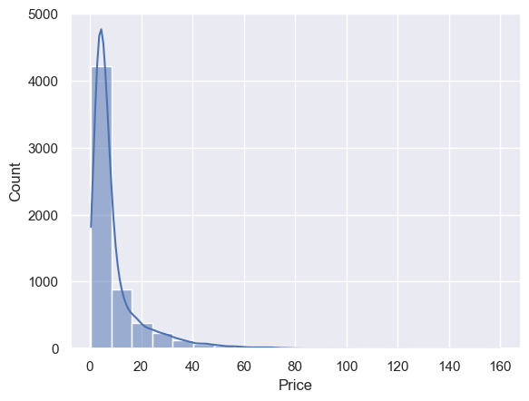

```python
sns.histplot(data=df, x="Price", kde=True, bins=20)
```

Price is skewed to the right.

```python
df["Fuel_Type"].value_counts()
```

```
Diesel      3852
Petrol      3325
CNG           62
LPG           12
Electric       2
Name: Fuel_Type, dtype: int64
```

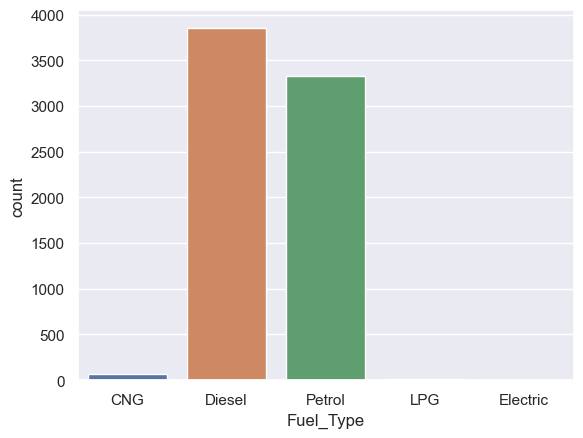

```python
sns.countplot(data=df, x="Fuel_Type")
```

Diesel has the highest market share, followed by petrol. The other fuel types have miniscule market share.

```python
# function to create labeled barplots


def labeled_barplot(data, feature, perc=False, n=None):
    """
    Barplot with percentage at the top

    data: dataframe
    feature: dataframe column
    perc: whether to display percentages instead of count (default is False)
    n: displays the top n category levels (default is None, i.e., display all levels)
    """

    total = len(data[feature])  # length of the column
    count = data[feature].nunique()
    if n is None:
        plt.figure(figsize=(count + 1, 5))
    else:
        plt.figure(figsize=(n + 1, 5))

    plt.xticks(rotation=90, fontsize=15)
    ax = sns.countplot(
        data=data,
        x=feature,
        palette="Paired",
        order=data[feature].value_counts().index[:n].sort_values(),
    )

    for p in ax.patches:
        if perc == True:
            label = "{:.1f}%".format(
                100 * p.get_height() / total
            )  # percentage of each class of the category
        else:
            label = p.get_height()  # count of each level of the category

        x = p.get_x() + p.get_width() / 2  # width of the plot
        y = p.get_height()  # height of the plot

        ax.annotate(
            label,
            (x, y),
            ha="center",
            va="center",
            size=12,
            xytext=(0, 5),
            textcoords="offset points",
        )  # annotate the percentage

    plt.show()  # show the plot
```

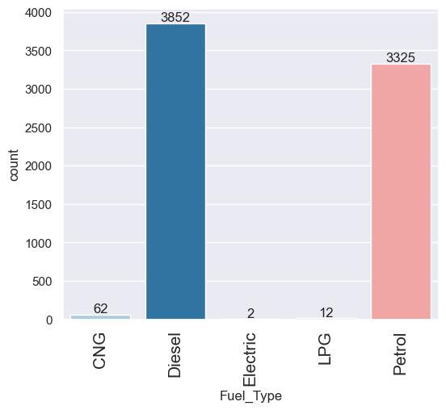

```python
labeled_barplot(df, "Fuel_Type")
```

Diesel and Petrol are the two fuel types that are leading the market. The fule types have very little market share

```python
df["Brand"] = df["Name"].str.split(" ").str[0]
df["Brand"].value_counts()
```

```
Maruti           1444
Hyundai          1340
Honda             743
Toyota            507
Mercedes-Benz     380
Volkswagen        374
Ford              351
Mahindra          331
BMW               312
Audi              285
Tata              228
Skoda             202
Renault           170
Chevrolet         151
Nissan            117
Land               67
Jaguar             48
Fiat               38
Mitsubishi         36
Mini               31
Volvo              28
Porsche            19
Jeep               19
Datsun             17
ISUZU               3
Force               3
Isuzu               2
Bentley             2
Smart               1
Ambassador          1
Lamborghini         1
Hindustan           1
OpelCorsa           1
Name: Brand, dtype: int64
```

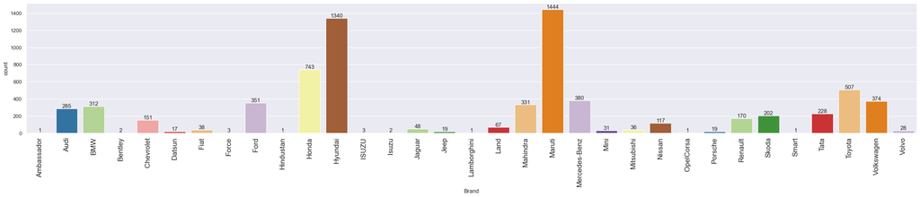

```python
labeled_barplot(df, "Brand")
```

Maruthi has the leading share in market closely followed by Hyundai.

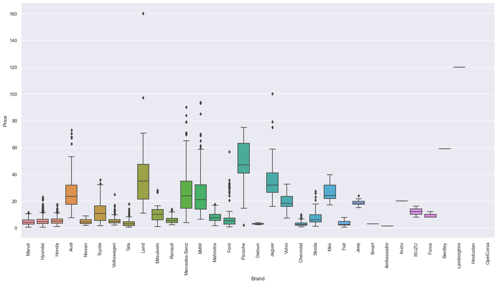

```python
plt.figure(figsize=(20, 10))
sns.boxplot(data=df, x="Brand", y="Price")
plt.xticks(rotation=90)
plt.show()
```

1. Maruthi and Hyundai that lead the market are in the low price ranges. Hyundai has a lot more outliers than Maruthi.

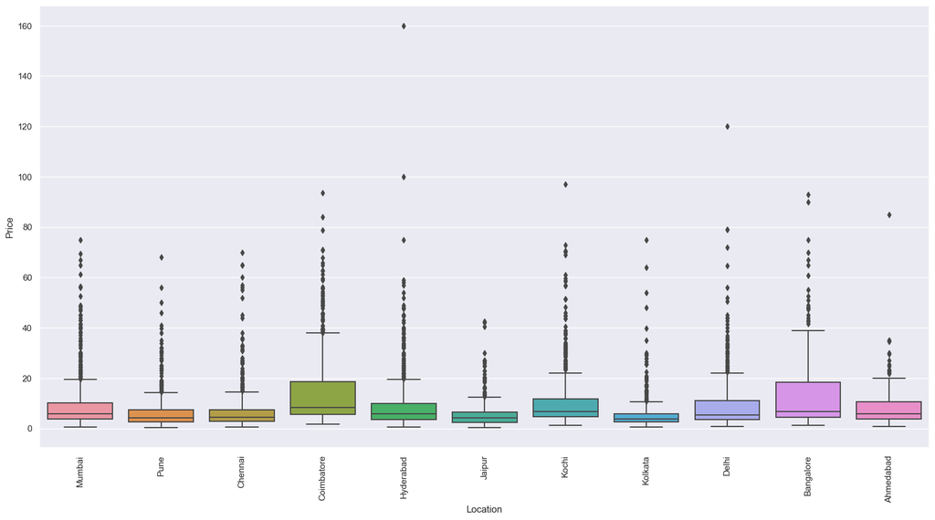

```python
plt.figure(figsize=(20, 10))
sns.boxplot(data=df, x="Location", y="Price")
plt.xticks(rotation=90)
plt.show()
```

IQR for all the locations are more or less similiar except Coimbatore and bangalore.

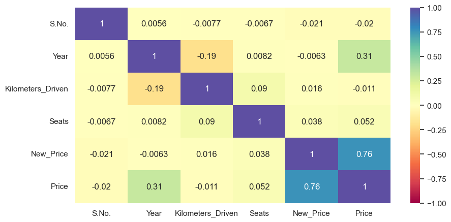

```python
plt.figure(figsize=(10, 5))
sns.heatmap(df.corr(), annot=True, cmap="Spectral", vmin=-1, vmax=1)
plt.show()
```

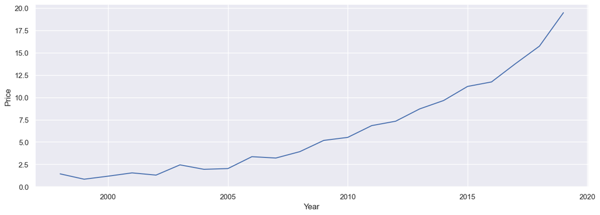

```python
plt.figure(figsize=(15, 5))
sns.lineplot(data=df, x="Year", y="Price", ci=None)
plt.show()
```

```python
def object_to_float(val):
    if isinstance(val, str):  # checks if `income_val` is a string

        return float(val.split(" ")[0])
    else:  # this happens when the current income is np.nan
        return np.nan


df["Engine_CC"] = df["Engine"].apply(object_to_float)
df["Power_val"] = df["Power"].apply(object_to_float)
```

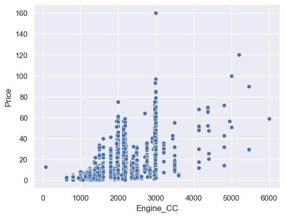

```python
sns.scatterplot(data=df, x="Engine_CC", y="Price")
```

## Data Preprocessing

- Missing value treatment
- Feature engineering (if needed)
- Outlier detection and treatment (if needed)
- Preparing data for modeling
- Any other preprocessing steps (if needed)

```python
df1 = df.copy()
```

```python
df1[["Mileage_reading", "mileage_unit"]] = df["Mileage"].apply(
    lambda x: pd.Series(str(x).split(" "))
)
print(df1["mileage_unit"].value_counts())
```

```
kmpl     7177
km/kg      74
Name: mileage_unit, dtype: int64
```

```python
df[df["Mileage"].isna()]
```

|  | S.No. | Name | Location | Year | Kilometers_Driven | Fuel_Type | Transmission | Owner_Type | Mileage | Engine | Power | Seats | New_Price | Price | Brand | Engine_CC | Power_val |
| --- | --- | --- | --- | --- | --- | --- | --- | --- | --- | --- | --- | --- | --- | --- | --- | --- | --- |
| 4446 | 4446 | Mahindra E Verito D4 | Chennai | 2016 | 50000 | Electric | Automatic | First | NaN | 72 CC | 41 bhp | 5.0 | 13.58 | 13.00 | Mahindra | 72.0 | 41.0 |
| 4904 | 4904 | Toyota Prius 2009-2016 Z4 | Mumbai | 2011 | 44000 | Electric | Automatic | First | NaN | 1798 CC | 73 bhp | 5.0 | 24.01 | 12.75 | Toyota | 1798.0 | 73.0 |

```python
df.dropna(subset=["Mileage"], inplace=True)
```

```python
Correct_Mileage = []
for i in df.Mileage:
    if str(i).endswith("km/kg"):
        i = i[:-6]
        i = float(i) * 1.40
        Correct_Mileage.append(float(i))
    elif str(i).endswith("kmpl"):
        i = i[:-6]
        # print(i)
        Correct_Mileage.append(float(i))
```

```python
df["Mileage"] = Correct_Mileage
```

```python
df.isnull().sum().sort_values(ascending=False)
```

```
Price                1234
Power_val             175
Power                 175
Seats                  53
Engine                 46
Engine_CC              46
Brand                   0
New_Price               0
S.No.                   0
Name                    0
Owner_Type              0
Transmission            0
Fuel_Type               0
Kilometers_Driven       0
Year                    0
Location                0
Mileage                 0
dtype: int64
```

##### Drop records that do not have price as it is a dependent variable

```python
df.dropna(subset=["Price"], inplace=True)
```

```python
df.drop("Power", axis=1, inplace=True)
```

```python
df.drop("Engine", axis=1, inplace=True)
```

```python
df.drop("S.No.", axis=1, inplace=True)
```

```python
df.reset_index(inplace=True, drop=True)
```

```python
num_missing = df.isnull().sum(axis=1)
num_missing.value_counts()
```

```
0    5872
1     105
3      36
2       4
dtype: int64
```

```python
df[df["Power_val"].isna()]
```

|  | Name | Location | Year | Kilometers_Driven | Fuel_Type | Transmission | Owner_Type | Mileage | Seats | New_Price | Price | Brand | Engine_CC | Power_val |
| --- | --- | --- | --- | --- | --- | --- | --- | --- | --- | --- | --- | --- | --- | --- |
| 76 | Ford Fiesta 1.4 SXi TDCi | Jaipur | 2008 | 111111 | Diesel | Manual | First | 17.0 | 5.0 | 11.685 | 2.00 | Ford | 1399.0 | NaN |
| 79 | Hyundai Santro Xing XL | Hyderabad | 2005 | 87591 | Petrol | Manual | First | 0.0 | 5.0 | 4.550 | 1.30 | Hyundai | 1086.0 | NaN |
| 89 | Hyundai Santro Xing XO | Hyderabad | 2007 | 73745 | Petrol | Manual | First | 17.0 | 5.0 | 4.550 | 2.10 | Hyundai | 1086.0 | NaN |
| 120 | Hyundai Santro Xing XL eRLX Euro III | Mumbai | 2005 | 102000 | Petrol | Manual | Second | 17.0 | 5.0 | 4.550 | 0.85 | Hyundai | 1086.0 | NaN |
| 143 | Hyundai Santro Xing XO eRLX Euro II | Kochi | 2008 | 80759 | Petrol | Manual | Third | 17.0 | 5.0 | 4.550 | 1.67 | Hyundai | 1086.0 | NaN |
| 194 | Honda City 1.5 GXI | Ahmedabad | 2007 | 60006 | Petrol | Manual | First | 0.0 | NaN | 13.580 | 2.95 | Honda | NaN | NaN |
| 208 | Maruti Swift 1.3 VXi | Kolkata | 2010 | 42001 | Petrol | Manual | First | 16.0 | NaN | 7.880 | 2.11 | Maruti | NaN | NaN |
| 227 | Maruti Swift VDI BSIV | Delhi | 2013 | 47000 | Diesel | Manual | First | 17.0 | 5.0 | 7.880 | 4.10 | Maruti | 1248.0 | NaN |
| 245 | Hyundai Santro Xing XO eRLX Euro II | Mumbai | 2007 | 72000 | Petrol | Manual | Third | 17.0 | 5.0 | 4.550 | 0.95 | Hyundai | 1086.0 | NaN |
| 262 | Hyundai Santro Xing XL | Hyderabad | 2006 | 99000 | Petrol | Manual | First | 0.0 | 5.0 | 4.550 | 1.75 | Hyundai | 1086.0 | NaN |
| 307 | Hyundai Santro Xing XL | Chennai | 2006 | 58000 | Petrol | Manual | Second | 0.0 | 5.0 | 4.550 | 1.50 | Hyundai | 1086.0 | NaN |
| 308 | Maruti Swift VDI BSIV | Kolkata | 2011 | 60020 | Diesel | Manual | First | 17.0 | 5.0 | 7.880 | 2.50 | Maruti | 1248.0 | NaN |
| 386 | Hyundai Santro Xing XL eRLX Euro III | Hyderabad | 2007 | 50958 | Petrol | Manual | First | 17.0 | 5.0 | 4.550 | 1.95 | Hyundai | 1086.0 | NaN |
| 424 | Volkswagen Jetta 2007-2011 1.9 L TDI | Hyderabad | 2010 | 42021 | Diesel | Manual | First | 0.0 | 5.0 | 10.150 | 5.45 | Volkswagen | 1968.0 | NaN |
| 428 | Hyundai Santro Xing XO eRLX Euro II | Pune | 2006 | 108000 | Petrol | Manual | Second | 17.0 | 5.0 | 4.550 | 1.20 | Hyundai | 1086.0 | NaN |
| 443 | Hyundai Santro GLS I - Euro I | Coimbatore | 2012 | 50243 | Petrol | Manual | First | 0.0 | 5.0 | 4.550 | 3.35 | Hyundai | 1086.0 | NaN |
| 472 | Ford Fiesta 1.6 SXI ABS Duratec | Chennai | 2009 | 80524 | Petrol | Manual | Second | 15.0 | 5.0 | 11.685 | 2.50 | Ford | 1596.0 | NaN |
| 575 | Hyundai Santro Xing XO | Chennai | 2006 | 83072 | Petrol | Manual | First | 17.0 | 5.0 | 4.550 | 1.40 | Hyundai | 1086.0 | NaN |
| 631 | Hyundai Santro LS zipPlus | Chennai | 2002 | 70000 | Petrol | Manual | Third | 0.0 | 5.0 | 4.550 | 0.65 | Hyundai | 1086.0 | NaN |
| 647 | Hyundai Santro Xing XP | Jaipur | 2004 | 200000 | Petrol | Manual | First | 0.0 | 5.0 | 4.550 | 0.80 | Hyundai | 1086.0 | NaN |
| 648 | Tata Indica DLS | Jaipur | 2009 | 82000 | Diesel | Manual | Second | 13.0 | 5.0 | 7.630 | 0.75 | Tata | 1405.0 | NaN |
| 733 | Maruti Swift 1.3 VXi | Chennai | 2006 | 97800 | Petrol | Manual | Third | 16.0 | NaN | 7.880 | 1.75 | Maruti | NaN | NaN |
| 739 | Maruti Swift VDI BSIV | Bangalore | 2007 | 60000 | Diesel | Manual | Second | 17.0 | 5.0 | 7.880 | 3.40 | Maruti | 1248.0 | NaN |
| 748 | Hyundai Santro Xing XO | Hyderabad | 2007 | 71297 | Petrol | Manual | First | 17.0 | 5.0 | 4.550 | 2.20 | Hyundai | 1086.0 | NaN |
| 749 | Land Rover Range Rover 3.0 D | Mumbai | 2008 | 55001 | Diesel | Automatic | Second | 0.0 | NaN | 120.000 | 26.50 | Land | NaN | NaN |
| 829 | Toyota Etios Liva G | Mumbai | 2012 | 29605 | Petrol | Manual | First | 18.0 | 5.0 | 8.525 | 2.44 | Toyota | 1197.0 | NaN |
| 915 | Smart Fortwo CDI AT | Pune | 2008 | 103000 | Diesel | Automatic | Second | 0.0 | 2.0 | 11.300 | 3.00 | Smart | 799.0 | NaN |
| 926 | Porsche Cayman 2009-2012 S | Hyderabad | 2010 | 10000 | Petrol | Manual | First | 9.0 | 2.0 | 136.000 | 40.00 | Porsche | 3436.0 | NaN |
| 934 | Toyota Etios GD | Kolkata | 2012 | 60000 | Diesel | Manual | First | 23.5 | 5.0 | 8.525 | 2.95 | Toyota | 1364.0 | NaN |
| 1068 | Toyota Etios Liva GD | Pune | 2012 | 225000 | Diesel | Manual | Second | 23.5 | 5.0 | 8.525 | 2.60 | Toyota | 1364.0 | NaN |

[output cut: 113 more lines]

```python
df["Power_val"] = df.groupby(["Brand", "Fuel_Type"])["Power_val"].transform(
    lambda x: x.fillna(x.median())
)
df.isnull().sum().sort_values(ascending=False)
```

```
Seats                42
Engine_CC            36
Power_val             2
Name                  0
Location              0
Year                  0
Kilometers_Driven     0
Fuel_Type             0
Transmission          0
Owner_Type            0
Mileage               0
New_Price             0
Price                 0
Brand                 0
dtype: int64
```

```python
df["Power_val"] = df.groupby(["Brand"])["Power_val"].transform(
    lambda x: x.fillna(x.median())
)
df.isnull().sum().sort_values(ascending=False)
```

```
Seats                42
Engine_CC            36
Power_val             1
Name                  0
Location              0
Year                  0
Kilometers_Driven     0
Fuel_Type             0
Transmission          0
Owner_Type            0
Mileage               0
New_Price             0
Price                 0
Brand                 0
dtype: int64
```

```python
df.dropna(subset=["Power_val"], inplace=True)
```

```python
df["Seats"] = df.groupby(["Brand", "Name"])["Seats"].transform(
    lambda x: x.fillna(x.median())
)
df.isnull().sum().sort_values(ascending=False)
```

```
Seats                36
Engine_CC            36
Name                  0
Location              0
Year                  0
Kilometers_Driven     0
Fuel_Type             0
Transmission          0
Owner_Type            0
Mileage               0
New_Price             0
Price                 0
Brand                 0
Power_val             0
dtype: int64
```

```python
df.drop("Name", axis=1, inplace=True)
df.reset_index(inplace=True, drop=True)
```

```python
df["Seats"] = df.groupby(["Brand"])["Seats"].transform(lambda x: x.fillna(x.median()))
df.isnull().sum().sort_values(ascending=False)
```

```
Engine_CC            36
Location              0
Year                  0
Kilometers_Driven     0
Fuel_Type             0
Transmission          0
Owner_Type            0
Mileage               0
Seats                 0
New_Price             0
Price                 0
Brand                 0
Power_val             0
dtype: int64
```

```python
df["Power_val"] = df.groupby(["Brand", "Power_val"])["Power_val"].transform(
    lambda x: x.fillna(x.median())
)
df.isnull().sum().sort_values(ascending=False)
```

```
Engine_CC            36
Location              0
Year                  0
Kilometers_Driven     0
Fuel_Type             0
Transmission          0
Owner_Type            0
Mileage               0
Seats                 0
New_Price             0
Price                 0
Brand                 0
Power_val             0
dtype: int64
```

```python
df["Engine_CC"] = df.groupby(["Brand"])["Engine_CC"].transform(
    lambda x: x.fillna(x.median())
)
```

```python
df.isnull().sum().sort_values(ascending=False)
```

```
Location             0
Year                 0
Kilometers_Driven    0
Fuel_Type            0
Transmission         0
Owner_Type           0
Mileage              0
Seats                0
New_Price            0
Price                0
Brand                0
Engine_CC            0
Power_val            0
dtype: int64
```

```python
df.head()
```

|  | Location | Year | Kilometers_Driven | Fuel_Type | Transmission | Owner_Type | Mileage | Seats | New_Price | Price | Brand | Engine_CC | Power_val |
| --- | --- | --- | --- | --- | --- | --- | --- | --- | --- | --- | --- | --- | --- |
| 0 | Mumbai | 2010 | 72000 | CNG | Manual | First | 37.24 | 5.0 | 5.51 | 1.75 | Maruti | 998.0 | 58.16 |
| 1 | Pune | 2015 | 41000 | Diesel | Manual | First | 19.60 | 5.0 | 16.06 | 12.50 | Hyundai | 1582.0 | 126.20 |
| 2 | Chennai | 2011 | 46000 | Petrol | Manual | First | 18.00 | 5.0 | 8.61 | 4.50 | Honda | 1199.0 | 88.70 |
| 3 | Chennai | 2012 | 87000 | Diesel | Manual | First | 20.70 | 7.0 | 11.27 | 6.00 | Maruti | 1248.0 | 88.76 |
| 4 | Coimbatore | 2013 | 40670 | Diesel | Automatic | Second | 15.00 | 5.0 | 53.14 | 17.74 | Audi | 1968.0 | 140.80 |

```python
df["Owner_Type"].value_counts()
```

```
First             4927
Second             967
Third              113
Fourth & Above       9
Name: Owner_Type, dtype: int64
```

```python
df["Seats"].value_counts()
```

```
5.0     5054
7.0      674
8.0      134
4.0       99
6.0       31
2.0       15
10.0       5
9.0        3
0.0        1
Name: Seats, dtype: int64
```

```python
df = df[df["Seats"] != 0.0]
```

```python
df["Fuel_Type"].value_counts()
```

```
Diesel    3204
Petrol    2745
CNG         56
LPG         10
Name: Fuel_Type, dtype: int64
```

```python
df["Transmission"].value_counts()
```

```
Manual       4299
Automatic    1716
Name: Transmission, dtype: int64
```

```python
df = pd.get_dummies(df, columns=["Transmission"], drop_first=True)
```

```python
df = pd.get_dummies(df, columns=["Fuel_Type"], drop_first=True)
```

```python
df = pd.get_dummies(df, columns=["Owner_Type"], drop_first=True)
```

```python
df = pd.get_dummies(df, columns=["Location"], drop_first=True)
```

```python
df = pd.get_dummies(df, columns=["Brand"], drop_first=True)
```

```python
df["Year"].value_counts()
```

```
2014    797
2015    744
2016    740
2013    649
2017    587
2012    579
2011    465
2010    342
2018    298
2009    198
2008    173
2007    125
2019    102
2006     78
2005     57
2004     31
2003     17
2002     15
2001      8
2000      4
1998      4
1999      2
Name: Year, dtype: int64
```

```python
# can add custom labels
df["Seats_bin"] = pd.cut(
    df["Seats"],
    [-np.inf, 5, 5 + 2, 10, np.inf],
    labels=["Under 5 seats", "5 seats", " 6 & 7", "above 7"],
)
```

```python
df = pd.get_dummies(df,columns= ["Seats_bin"], drop_first=True)
```

```python
df.head()
```

|  | Year | Kilometers_Driven | Mileage | Seats | New_Price | Price | Engine_CC | Power_val | Transmission_Manual | Fuel_Type_Diesel | Fuel_Type_LPG | Fuel_Type_Petrol | Owner_Type_Fourth & Above | Owner_Type_Second | Owner_Type_Third | Location_Bangalore | Location_Chennai | Location_Coimbatore | Location_Delhi | Location_Hyderabad | Location_Jaipur | Location_Kochi | Location_Kolkata | Location_Mumbai | Location_Pune | Brand_Audi | Brand_BMW | Brand_Bentley | Brand_Chevrolet | … |
| --- | --- | --- | --- | --- | --- | --- | --- | --- | --- | --- | --- | --- | --- | --- | --- | --- | --- | --- | --- | --- | --- | --- | --- | --- | --- | --- | --- | --- | --- | --- |
| 0 | 2010 | 72000 | 37.24 | 5.0 | 5.51 | 1.75 | 998.0 | 58.16 | 1 | 0 | 0 | 0 | 0 | 0 | 0 | 0 | 0 | 0 | 0 | 0 | 0 | 0 | 0 | 1 | 0 | 0 | 0 | 0 | 0 | … |
| 1 | 2015 | 41000 | 19.60 | 5.0 | 16.06 | 12.50 | 1582.0 | 126.20 | 1 | 1 | 0 | 0 | 0 | 0 | 0 | 0 | 0 | 0 | 0 | 0 | 0 | 0 | 0 | 0 | 1 | 0 | 0 | 0 | 0 | … |
| 2 | 2011 | 46000 | 18.00 | 5.0 | 8.61 | 4.50 | 1199.0 | 88.70 | 1 | 0 | 0 | 1 | 0 | 0 | 0 | 0 | 1 | 0 | 0 | 0 | 0 | 0 | 0 | 0 | 0 | 0 | 0 | 0 | 0 | … |
| 3 | 2012 | 87000 | 20.70 | 7.0 | 11.27 | 6.00 | 1248.0 | 88.76 | 1 | 1 | 0 | 0 | 0 | 0 | 0 | 0 | 1 | 0 | 0 | 0 | 0 | 0 | 0 | 0 | 0 | 0 | 0 | 0 | 0 | … |
| 4 | 2013 | 40670 | 15.00 | 5.0 | 53.14 | 17.74 | 1968.0 | 140.80 | 0 | 1 | 0 | 0 | 0 | 1 | 0 | 0 | 0 | 1 | 0 | 0 | 0 | 0 | 0 | 0 | 0 | 1 | 0 | 0 | 0 | … |

```python
df.drop(["Seats"], axis=1, inplace=True)
```

```python
df.reset_index(inplace=True, drop=True)
```

```python
# function to plot a boxplot and a histogram along the same scale.


def histogram_boxplot(data, feature, figsize=(12, 7), kde=False, bins=None):
    """
    Boxplot and histogram combined

    data: dataframe
    feature: dataframe column
    figsize: size of figure (default (12,7))
    kde: whether to the show density curve (default False)
    bins: number of bins for histogram (default None)
    """
    f2, (ax_box2, ax_hist2) = plt.subplots(
        nrows=2,  # Number of rows of the subplot grid= 2
        sharex=True,  # x-axis will be shared among all subplots
        gridspec_kw={"height_ratios": (0.25, 0.75)},
        figsize=figsize,
    )  # creating the 2 subplots
    sns.boxplot(
        data=data, x=feature, ax=ax_box2, showmeans=True, color="violet"
    )  # boxplot will be created and a star will indicate the mean value of the column
    sns.histplot(
        data=data, x=feature, kde=kde, ax=ax_hist2, bins=bins, palette="winter"
    ) if bins else sns.histplot(
        data=data, x=feature, kde=kde, ax=ax_hist2
    )  # For histogram
    ax_hist2.axvline(
        data[feature].mean(), color="green", linestyle="--"
    )  # Add mean to the histogram
    ax_hist2.axvline(
        data[feature].median(), color="black", linestyle="-"
    )  # Add median to the histogram
```

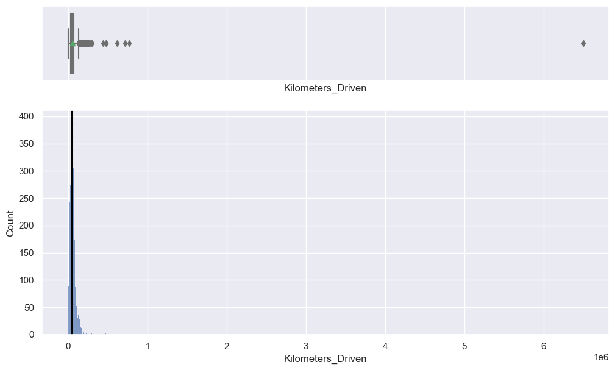

```python
histogram_boxplot(df, "Kilometers_Driven")
```

```python
df["Kilometers_Driven_log"] = np.log(df["Kilometers_Driven"])
```

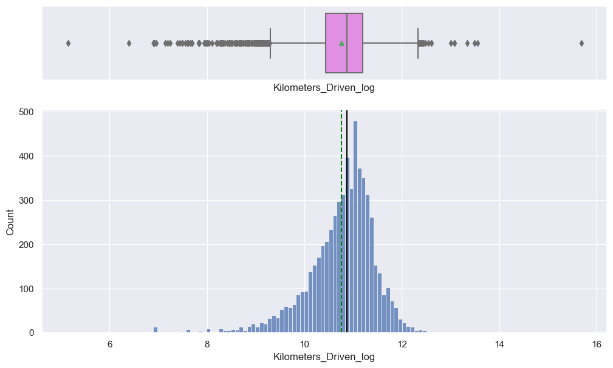

```python
histogram_boxplot(df, "Kilometers_Driven_log")
```

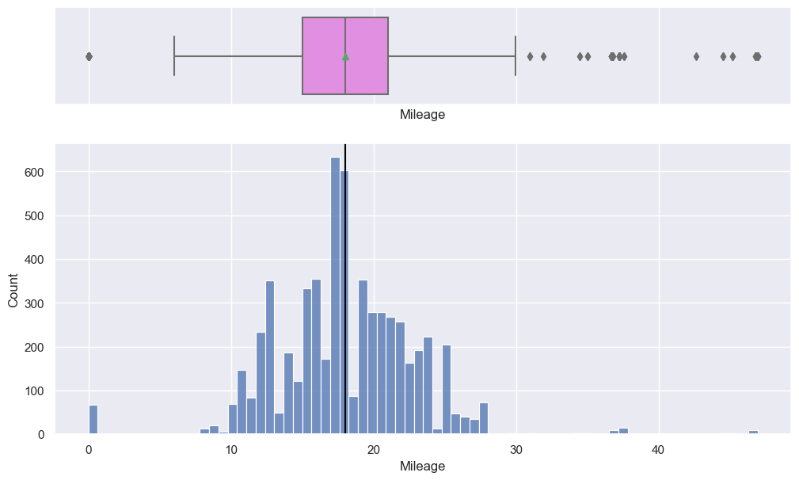

```python
histogram_boxplot(df, "Mileage")
```

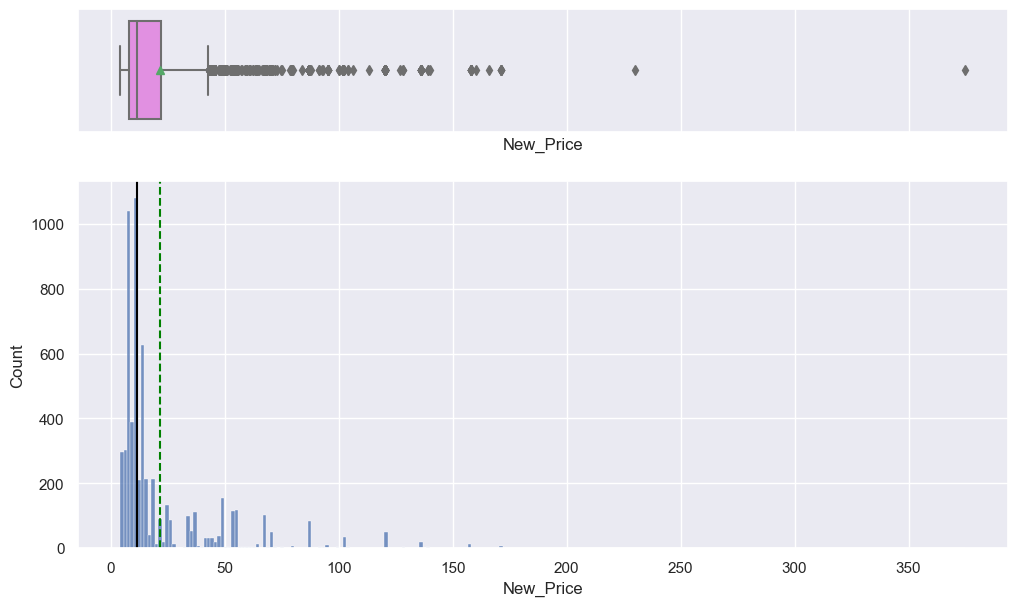

```python
histogram_boxplot(df, "New_Price")
```

```python
df["New_Price"] = np.log(df["New_Price"])
```

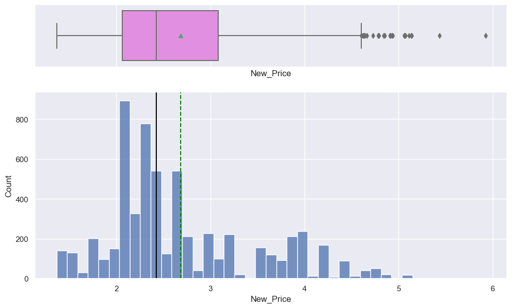

```python
histogram_boxplot(df, "New_Price")
```

```python
df["Price"] = abs(np.log(df["Price"] + 1))
```

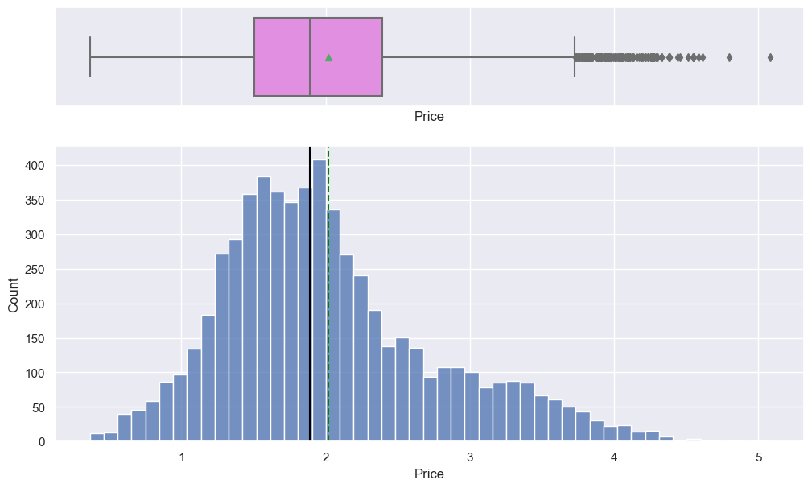

```python
histogram_boxplot(df, "Price")
```

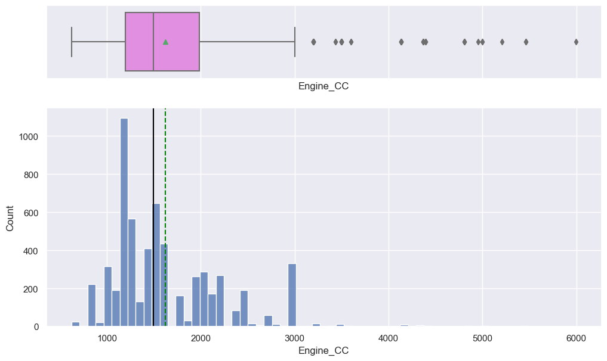

```python
histogram_boxplot(df, "Engine_CC")
```

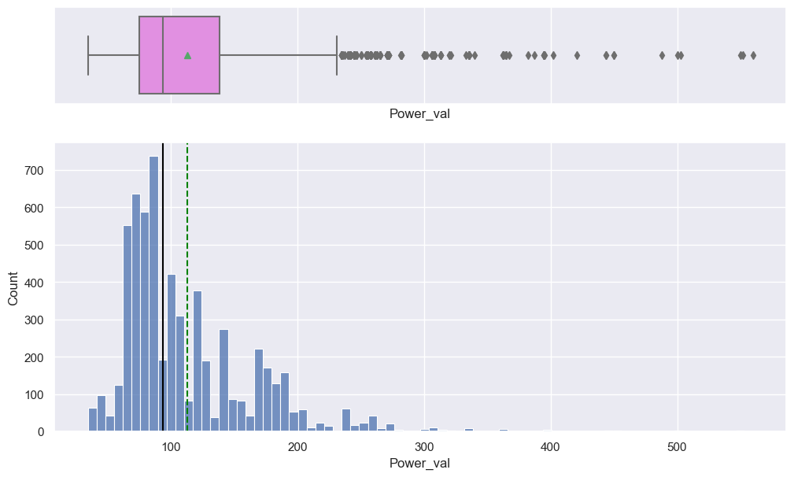

```python
histogram_boxplot(df, "Power_val")
```

```python
df.describe().T
```

|  | count | mean | std | min | 25% | 50% | 75% | max |
| --- | --- | --- | --- | --- | --- | --- | --- | --- |
| Year | 6015.0 | 2013.359268 | 3.269734 | 1998.000000 | 2011.000000 | 2014.000000 | 2016.000000 | 2.019000e+03 |
| Kilometers_Driven | 6015.0 | 58723.908728 | 91293.139408 | 171.000000 | 34000.000000 | 53000.000000 | 73000.000000 | 6.500000e+06 |
| Mileage | 6015.0 | 17.994691 | 4.882924 | 0.000000 | 15.000000 | 18.000000 | 21.000000 | 4.695600e+01 |
| New_Price | 6015.0 | 2.683387 | 0.797441 | 1.363537 | 2.064328 | 2.424803 | 3.080533 | 5.926926e+00 |
| Price | 6015.0 | 2.018176 | 0.748247 | 0.364643 | 1.504077 | 1.893112 | 2.393339 | 5.081404e+00 |
| Engine_CC | 6015.0 | 1620.533500 | 599.829479 | 624.000000 | 1197.000000 | 1493.000000 | 1984.000000 | 5.998000e+03 |
| Power_val | 6015.0 | 112.899706 | 53.772542 | 34.200000 | 75.000000 | 93.700000 | 138.100000 | 5.600000e+02 |
| Transmission_Manual | 6015.0 | 0.714713 | 0.451588 | 0.000000 | 0.000000 | 1.000000 | 1.000000 | 1.000000e+00 |
| Fuel_Type_Diesel | 6015.0 | 0.532668 | 0.498973 | 0.000000 | 0.000000 | 1.000000 | 1.000000 | 1.000000e+00 |
| Fuel_Type_LPG | 6015.0 | 0.001663 | 0.040743 | 0.000000 | 0.000000 | 0.000000 | 0.000000 | 1.000000e+00 |
| Fuel_Type_Petrol | 6015.0 | 0.456359 | 0.498133 | 0.000000 | 0.000000 | 0.000000 | 1.000000 | 1.000000e+00 |
| Owner_Type_Fourth & Above | 6015.0 | 0.001496 | 0.038656 | 0.000000 | 0.000000 | 0.000000 | 0.000000 | 1.000000e+00 |
| Owner_Type_Second | 6015.0 | 0.160765 | 0.367344 | 0.000000 | 0.000000 | 0.000000 | 0.000000 | 1.000000e+00 |
| Owner_Type_Third | 6015.0 | 0.018786 | 0.135781 | 0.000000 | 0.000000 | 0.000000 | 0.000000 | 1.000000e+00 |
| Location_Bangalore | 6015.0 | 0.059518 | 0.236611 | 0.000000 | 0.000000 | 0.000000 | 0.000000 | 1.000000e+00 |
| Location_Chennai | 6015.0 | 0.081962 | 0.274329 | 0.000000 | 0.000000 | 0.000000 | 0.000000 | 1.000000e+00 |
| Location_Coimbatore | 6015.0 | 0.105736 | 0.307525 | 0.000000 | 0.000000 | 0.000000 | 0.000000 | 1.000000e+00 |
| Location_Delhi | 6015.0 | 0.092103 | 0.289195 | 0.000000 | 0.000000 | 0.000000 | 0.000000 | 1.000000e+00 |
| Location_Hyderabad | 6015.0 | 0.123192 | 0.328685 | 0.000000 | 0.000000 | 0.000000 | 0.000000 | 1.000000e+00 |
| Location_Jaipur | 6015.0 | 0.068662 | 0.252899 | 0.000000 | 0.000000 | 0.000000 | 0.000000 | 1.000000e+00 |
| Location_Kochi | 6015.0 | 0.108229 | 0.310696 | 0.000000 | 0.000000 | 0.000000 | 0.000000 | 1.000000e+00 |
| Location_Kolkata | 6015.0 | 0.088944 | 0.284687 | 0.000000 | 0.000000 | 0.000000 | 0.000000 | 1.000000e+00 |
| Location_Mumbai | 6015.0 | 0.131172 | 0.337617 | 0.000000 | 0.000000 | 0.000000 | 0.000000 | 1.000000e+00 |
| Location_Pune | 6015.0 | 0.103242 | 0.304300 | 0.000000 | 0.000000 | 0.000000 | 0.000000 | 1.000000e+00 |
| Brand_Audi | 6015.0 | 0.039069 | 0.193775 | 0.000000 | 0.000000 | 0.000000 | 0.000000 | 1.000000e+00 |
| Brand_BMW | 6015.0 | 0.044389 | 0.205975 | 0.000000 | 0.000000 | 0.000000 | 0.000000 | 1.000000e+00 |
| Brand_Bentley | 6015.0 | 0.000166 | 0.012894 | 0.000000 | 0.000000 | 0.000000 | 0.000000 | 1.000000e+00 |
| Brand_Chevrolet | 6015.0 | 0.020116 | 0.140410 | 0.000000 | 0.000000 | 0.000000 | 0.000000 | 1.000000e+00 |
| Brand_Datsun | 6015.0 | 0.002161 | 0.046443 | 0.000000 | 0.000000 | 0.000000 | 0.000000 | 1.000000e+00 |
| Brand_Fiat | 6015.0 | 0.004655 | 0.068074 | 0.000000 | 0.000000 | 0.000000 | 0.000000 | 1.000000e+00 |
| Brand_Force | 6015.0 | 0.000499 | 0.022329 | 0.000000 | 0.000000 | 0.000000 | 0.000000 | 1.000000e+00 |
| Brand_Ford | 6015.0 | 0.049875 | 0.217705 | 0.000000 | 0.000000 | 0.000000 | 0.000000 | 1.000000e+00 |
| Brand_Honda | 6015.0 | 0.101081 | 0.301461 | 0.000000 | 0.000000 | 0.000000 | 0.000000 | 1.000000e+00 |
| Brand_Hyundai | 6015.0 | 0.184040 | 0.387549 | 0.000000 | 0.000000 | 0.000000 | 0.000000 | 1.000000e+00 |
| Brand_ISUZU | 6015.0 | 0.000333 | 0.018233 | 0.000000 | 0.000000 | 0.000000 | 0.000000 | 1.000000e+00 |
| Brand_Isuzu | 6015.0 | 0.000166 | 0.012894 | 0.000000 | 0.000000 | 0.000000 | 0.000000 | 1.000000e+00 |
| Brand_Jaguar | 6015.0 | 0.006650 | 0.081283 | 0.000000 | 0.000000 | 0.000000 | 0.000000 | 1.000000e+00 |
| Brand_Jeep | 6015.0 | 0.002494 | 0.049879 | 0.000000 | 0.000000 | 0.000000 | 0.000000 | 1.000000e+00 |
| Brand_Lamborghini | 6015.0 | 0.000166 | 0.012894 | 0.000000 | 0.000000 | 0.000000 | 0.000000 | 1.000000e+00 |
| Brand_Land | 6015.0 | 0.009975 | 0.099384 | 0.000000 | 0.000000 | 0.000000 | 0.000000 | 1.000000e+00 |
| Brand_Mahindra | 6015.0 | 0.045054 | 0.207440 | 0.000000 | 0.000000 | 0.000000 | 0.000000 | 1.000000e+00 |
| Brand_Maruti | 6015.0 | 0.201330 | 0.401027 | 0.000000 | 0.000000 | 0.000000 | 0.000000 | 1.000000e+00 |
| Brand_Mercedes-Benz | 6015.0 | 0.052868 | 0.223788 | 0.000000 | 0.000000 | 0.000000 | 0.000000 | 1.000000e+00 |
| Brand_Mini | 6015.0 | 0.004323 | 0.065609 | 0.000000 | 0.000000 | 0.000000 | 0.000000 | 1.000000e+00 |
| Brand_Mitsubishi | 6015.0 | 0.004489 | 0.066853 | 0.000000 | 0.000000 | 0.000000 | 0.000000 | 1.000000e+00 |
| Brand_Nissan | 6015.0 | 0.015129 | 0.122076 | 0.000000 | 0.000000 | 0.000000 | 0.000000 | 1.000000e+00 |
| Brand_Porsche | 6015.0 | 0.002993 | 0.054627 | 0.000000 | 0.000000 | 0.000000 | 0.000000 | 1.000000e+00 |
| Brand_Renault | 6015.0 | 0.024106 | 0.153392 | 0.000000 | 0.000000 | 0.000000 | 0.000000 | 1.000000e+00 |
| Brand_Skoda | 6015.0 | 0.028761 | 0.167149 | 0.000000 | 0.000000 | 0.000000 | 0.000000 | 1.000000e+00 |
| Brand_Tata | 6015.0 | 0.030923 | 0.173123 | 0.000000 | 0.000000 | 0.000000 | 0.000000 | 1.000000e+00 |
| Brand_Toyota | 6015.0 | 0.068163 | 0.252046 | 0.000000 | 0.000000 | 0.000000 | 0.000000 | 1.000000e+00 |
| Brand_Volkswagen | 6015.0 | 0.052369 | 0.222789 | 0.000000 | 0.000000 | 0.000000 | 0.000000 | 1.000000e+00 |
| Brand_Volvo | 6015.0 | 0.003491 | 0.058989 | 0.000000 | 0.000000 | 0.000000 | 0.000000 | 1.000000e+00 |
| Seats_bin_5 seats | 6015.0 | 0.117207 | 0.321694 | 0.000000 | 0.000000 | 0.000000 | 0.000000 | 1.000000e+00 |
| Seats_bin_ 6 & 7 | 6015.0 | 0.023608 | 0.151836 | 0.000000 | 0.000000 | 0.000000 | 0.000000 | 1.000000e+00 |
| Seats_bin_above 7 | 6015.0 | 0.000000 | 0.000000 | 0.000000 | 0.000000 | 0.000000 | 0.000000 | 0.000000e+00 |
| Kilometers_Driven_log | 6015.0 | 10.758488 | 0.715843 | 5.141664 | 10.434116 | 10.878047 | 11.198215 | 1.568731e+01 |